# Symulacje Monte Carlo i Bootstraping w środowisku R (234240-D)

Lab #3

Uladzislau Darhevich

2021-11-27

# 1. Geometryczny Ruch Browna - zadanie

Zasymuluj kształtowanie ścieżki cen przy założeniach:

$\ S_t = S_0\exp\left((\mu-\frac{\sigma^2}{2})\Delta t + \sigma\sqrt{\Delta t}Z \right)$

gdzie Z ∼ N(0, 1), n = 1000, µ = 1, σ = 0.8, $\ S_0$ = 100.

```r
library(ggplot2)
library(tidyverse)
library(pander)
set.seed(42)

GRB <- function(nsim = 100, t = 25, mu = 0, sigma = 0.1, S0 = 100, dt = 1./365) {
  # matrix of random draws - one for each day for each simulation
  z <- matrix(rnorm(t*nsim), ncol = nsim, nrow = t)
  # get GBM and convert to price paths
  gbm <- exp((mu - sigma * sigma / 2) * dt + sigma * z * sqrt(dt))
  gbm <- apply(rbind(rep(S0, nsim), gbm), 2, cumprod)
  return(gbm)
}

rb1 <- GRB(1000, 22, 1, 0.8, 100)

df <- as.data.frame(rb1) %>%
  mutate(ix = 1:nrow(rb1)) %>%
  pivot_longer(-ix, names_to = 'sim', values_to = 'price')
```

Wizualizacja symulacji

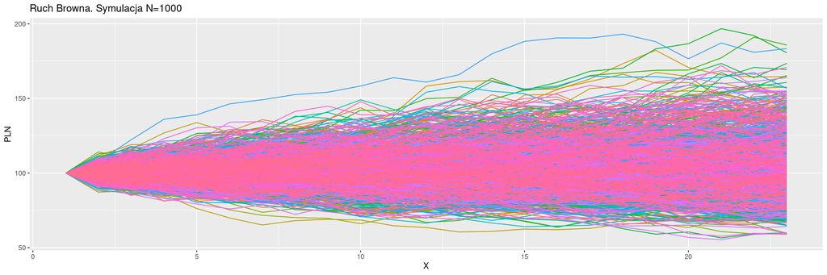

# 2. Opcje europejskie

- 196PLN
- 161PLN
- 170PLN

[output not shown]

```r
BlackScholes <- function(S, K, r, T, sig, type){
  # S = Stock Price
  # K = Strike Price at Expiration
  # r = Risk-free Interest Rate
  # T = Time to Expiration
  # sig = Volatility of the Underlying asset
  if(type=="C"){
    d1 <- (log(S/K) + (r + sig^2/2)*T) / (sig*sqrt(T))
    d2 <- d1 - sig*sqrt(T)

    value <- S*pnorm(d1) - K*exp(-r*T)*pnorm(d2)
    return(value)}

  if(type=="P"){
    d1 <- (log(S/K) + (r + sig^2/2)*T) / (sig*sqrt(T))
    d2 <- d1 - sig*sqrt(T)

    value <-  (K*exp(-r*T)*pnorm(-d2) - S*pnorm(-d1))
    return(value)}
}
prices <- c(196, 161, 170)
calls <- lapply(prices, BlackScholes, S=184, r=0.03, T=3/52, sig=0.2, type="C")
puts <- lapply(prices, BlackScholes, S=184, r=0.03, T=3/52, sig=0.2, type="P")
df <- data.frame(unlist(prices), unlist(calls), unlist(puts))
names(df) <- c("Cena opcji, PLN", "CALL", "PUT")
pander(df, type = 'grid')
```

| Cena opcji, PLN | CALL | PUT |
| --- | --- | --- |
| 196 | 0.4336 | 12.09 |
| 161 | 23.28 | 0.005962 |
| 170 | 14.46 | 0.1616 |

# 3. Praca domowa

A coin is tossed n times, thereby generating a sequence of heads (H) and tails (T). A subsequence of consecutive heads is called a run of heads. Consequently, the following sequence *HHTHTTHHHHTTTHHTTTTH* of length n = 20 contains 5 runs of heads with lengths 2,1,4,2,1, respectively. The longest run of heads is Mn = 4.

- Write a function (in R) which generates random sequences of heads and tails for any value of n.
- Write a function which computes the length of the longest run of heads in an arbitrary sequence of heads and tails.
- For a sequence of length n = 1000, we have observed a longest run of heads equal to Mn = 6. Based on your decision on this piece of information, do you believe that the coin is fair or not?

Funkcja do generacji losowej sekwencje orłów i reszek dla dowolnej wartości N:

```r
generate_values <- function(N, values){
  #N - number of values to generate
  #values - list of values to generate, e.g "H", "T"
  z <- sample(size = N,
              x = values,
              replace = TRUE)
  return(z)
}
```

Funkcja, która oblicza długość najdłuższej serii orłów w dowolnej kolejności orłów i reszek:

```r
longest_run <- function(x){
  #x - sequence of some values
  z <- tapply(rle(x)$lengths, rle(x)$values, FUN=max)
  return(z)
}
```

Wygenerujmy losową sekwencję orłów i reszek N = 1000 i obliczmy długość najdłuższego biegu orłów oraz reszek. Zróbmy to 10000 razy i obliczmy śriedną

```r
average_num_of_heads <- function(N){
  tmp <- replicate(N, longest_run(generate_values(1000, c("H", "T")))["H"], simplify=TRUE)
  return(round(mean(tmp), 0))
}
average_head_run <- average_num_of_heads(10000)

p <- 0.5
n <- 1000
L <- round(-log(n*(1-p), base=p), 0)
```

Śriednia długość serii według symulacji wynosi 9.

Na podstawie [artukułu](https://alexamarioarei.github.io/Research/docs/LongestHrunReview.pdf) oraz [linka](https://math.stackexchange.com/questions/1409372/what-is-the-expected-length-of-the-largest-run-of-heads-if-we-make-1-000-flips) teoretyczny najdłuższy przebieg orłów można oszacować za pomocą wzoru $\ L \approx -\log _p n(1-p)$, gdzie p=0.5. Wtedy dla N = 1000 L wynosi 9.

Na podstawie obliczeń teoretycznych i symulacji można stwierdzić, że moneta *nie jest uczciwą*.